# GRAD-C6-2001: Statistics II - Final Replication Paper

Preventing and Responding to Dissent: The Observational Challenges of Explaining Strategic Repression.

Giorgio Coppola - 224545

June 05, 2023 | 11:21:11 | CEST

### Fact sheet

**Abstract**: Although scholarly consensus suggests that dissent causes repression, the behaviors are endoge- nous: governments and dissidents act in expectation of each other’s behavior. Empirical studies have not accounted well for this endogeneity. We argue that preventive aspects of repression meaningfully affect the relationship between observed dissent and repression. When governments use preventive repression, the best response to dissent that does occur is unclear; observed dissent does not meaningfully predict responsive repression. By contrast, governments that do not engage in ex ante repression will be more likely to do it ex post. We follow U.S. voting scholarship and propose a new instrument to model the endogeneity: rainfall. We couple rainfall data in African provinces and U.S. states with data on dissent and repression and find that dissent fails to have a significant effect on responsive repression in states that engage in preventive repression.

**What it is about**: The study analyses the relationship between dissent and repression. The authors argue that most empirical research fails to account for the endogeneity that characterises both phenomena. In fact, it can be argued that the groups that mobilise (dissent) and those that violate (repression) decide how to act by anticipating what the other group will do. Dissidents may self-censor in anticipation of repression, while governments may preemptively repress in anticipation of dissent. This could have implications for the previously theorised positive relationship between dissent and repression. Moreover, the authors account for differences in democracies and in non-democracies, using this as a proxy to understand the role of preventive repression, which is assumed to be higher in non-democratic regimes. It is expected that in non-democratic regimes, namely where preventive repression is more probable, there is not a clear relationship between dissent and repression.

Two main hypothesis are tested: - *Hypothesis 1*: When a government has engaged in preventive repression, an increase in manifest dissent will not be associated with an increase in reactive repression. - *Hypothesis 2*: When a government has not engaged in preventive repression, an increase in manifest dissent will be associated with an increase in responsive repression.

**Data used**: To increase the external validity of the results, the study is carried out using cross-sectional data from Africa and the US.

*Africa* - Conflict data: Social Conflict Analysis Database (SCAD), with data on contentious events (governmental and non-governmental) that occurred in all states on the continent with at least 1 million people between 1990 and 2013. The events are geocoded and defined using AP and AFP news wires. It is used to identify mobilised dissent and responsive (state) repression. - Mobilized dissent: total number of organised and spontaneous demonstrations, organized and spontaneous violent riots, general and limited strikes, and other anti-government violence that occurred on a given day in a province. - State (‘responsive’) repression: count of all incidents in which the government responded to dissent, regardless of severity. - Rainfall (IV): Africa Rainfall Estimate Climatology (ARC2), using the records between 01/01/1990 and 31/12/2012 and mapping them using the Global Administrative Layers (GAUL) dataset to define the relevant first-order administrative bondaries. The estimation is done using the logarithm of daily precipitation totals. - Unified Democracy Score: using the mean of the state to define whether it is a democracy or not, assuming that the impact of dissent on repression differs between democratic and non-democratic states. This allows the likelihood of preemptive repression to be taken into account. - Urbanzsation: Global Rural-Urban Mapping Project, used to control for the likelihood of participating in a protest on a rainy day if you live in an urban area.

*United States* - Conflict data: Dynamics of Collective Action (DCA) dataset, coding details of 17,000 protests (violent and non-violent) that occurred in the 620 cities in the 48 states (excluding Hawaii and Alaska) between 1960 and 1995. - Mobilized dissent: daily sum of all dissent events that occurred in any city in a given state. - State Repression: daily count of the number of events to which the police responded with some form of repression. - Precipitation (IV): U.S. Historical Climatology Network (USHCN), a subset of the U.S. Cooperative Observer Network operated by NOAA’s National Weather Service (NWS). Each protest observation was paired with the nearest weather station. - Urbanization: data from Lindquist (2007).

**Empirical strategy**: To solve the problem caused by endogeneity in this context, the authors uses an *instrumental variable approach*, using rainfall levels as an instrument to extract the exogenous part of dissent and test it against repression, connecting precipitation patterns to political violence. The variable ‘rainfall’ seems to responds to the 4 assumptions needed to consider an instrument as valid. The authors assume it to can play a role in dissuading people from dissenting (relevancy), and that at the same time, it does not impact repressive action (exclusion restriction), and there are no confounding structure in the relationship between ‘rainfall’ and ‘dissent’ (independence). Using an instrumental variable allows to only consider the exogenous part of the independent variable when inferring a causal relationship between it and the dependent one. Considering the theorized endogeneity of the two variables of interest, using an instrument that constitutes an encouragement (or not) to dissent would help to account for its actual effect on repression. The authors also use *coarsened exact matching* between units which differ in terms of rainfall but with similar values of the covariates democracy and urbanization. This increases the plausibility of treatment assignment being as-if-random and improves comparability. Indeed, doing so in this study will reduce the possibility of the results being effect of a selection bias and will allow to compare the results between units with and without rainfall, and to test the formulated hypothesis about causality.

**Main findings**: Concerning the African (Province-Day) dataset, according to the naive model, the law of coercive responsiveness is confirmed: Mobilized dissent is positively and significantly related to state repression. However, using the instrumental variable regression, dissent no longer has a statistically significant effect on repression. The analysis distinguishes between democracies and non-democracies. According to the IV regression, dissent has an increasingly positive effect on responsive repression in the sample of democracies. In contrast, for non-democracies there is no statistically significant relationship between dissent and repression. Moreover, according to the F test estimate, rainfall is a strong instrumental variable and therefore a valid explanatory instrument.

Concerning the US (State-Day) dataset, the naive model suggests a positive, statistically significant relationship between mobilised dissent and state repression. Moreover, in the IV model, the coefficient on dissent is also positive and statistically significant at the 95% confidence level.

The causal setup implied by the authors can be illustrated by the following **DAG** In the DAG, I put two confounders: preventive repression (operationalized with the dummy variable ‘democracy’), and urbanization (a continuous variable). Both of them are both related to dissent and to repression.

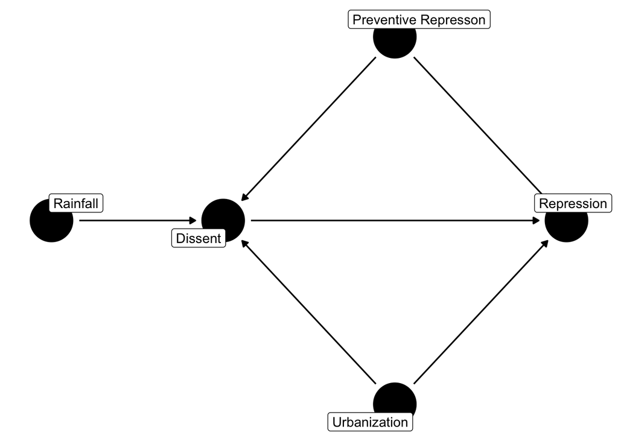

```r
coord_dag <- list(
  x = c(rain = 0, diss = 1, dem = 2, urb = 2, repr = 3),
  y = c(rain = 0, diss = 0, dem = 1, urb = -1, repr = 0))

dag1 <- ggdag::dagify(diss ~ rain,
                      repr ~ diss,
                      diss ~ dem,
                      repr ~ dem,
                      diss ~ urb,
                      repr ~ urb,
                      labels = c("rain" = "Rainfall",
                                  "diss" = "Dissent",
                                  "dem" = "Preventive Represson",
                                  "urb" = "Urbanization",
                                  "repr" = "Repression"),
                          latent = "dem",
                          exposure = "diss",
                          outcome = "repr",
                          coords = coord_dag)

ggdag(dag1, text = FALSE, use_labels = "label") +
  theme_void()
```

### Replication

The following code replicates Table 1 of the paper “Preventing and Responding to Dissent: The Observational Challenges of Explaining Strategic Repression”, displaying the outcomes obtained from the two-stage least squares (2SLS) estimations for the African sample. It illustrate the effect of mobilized dissent on state repression, and it consists of 6 columns showing the results of 4 different models and guiding the reader through the steps taken by the researchers:

- **Column 1** shows the results of the naive regression, which considers only the effect of mobilized dissent on repression, controlling for urbanisation;
- **Column 2** shows a baseline model that now includes the instrument (rainfall) but does not distinguish between democracies and non-democracies (i.e. preventive repression);
- **Columns 3 and 4** extend the results of Column 2, now distinguishing between democracies and non-democracies;
- **Columns 5 and 6** also includes a matching logic in which provinces are matched on the basis of the democratic regime and the level of urbanisation, differing only on the presence or absence of rainfall.

For clarity, the original table has been divided into two different tables, one showing the first stage, and the other showing the second stage.

```r
options("scipen"=999)

# Merging the datasets and ordering the newly created one
africa_new <- africa_data %>%
  dplyr::arrange(cow, year) %>%
  tsibble::as_tibble() %>%
  plm::pdata.frame(, index = c("adm0_adm1", "date")) %>%
  dplyr::left_join(lat_dem, by = c("cow", "year")) %>%
  dplyr::rename(latent_democracy = mean) %>%
  tsibble::as_tibble() %>%
  plm::pdata.frame(, index = c("adm0_adm1", "date")) %>% # Creating the variables dissentcount and represscount
  dplyr::mutate(dissentcount = etype2 + etype3 + etype4 + etype5 + etype6 + etype8 +
                          escalation1 + escalation2 + escalation3 + escalation4 +
                          escalation5 + escalation6 + escalation8) %>%
  dplyr::mutate(represscount = escalation7 + repBINARYone + repBINARYtwo) %>% # Dropping the unnecessary variables
  dplyr::select(-etype2, -etype3, -etype4, -etype5, -etype6, -etype7, -etype8,
         -etype9, -etype10, -escalation0, -escalation1, -escalation2, -escalation3,
         -escalation4, -escalation5, -escalation6, -escalation7, -escalation8,
         -escalation9, -escalation10, -etypeNEG9, -repBINARYone, -repBINARYtwo,
         -repBINARYzero) %>% # Creating the variables repressbinary and dissentbinary
  dplyr::mutate(repressbinary = ifelse(represscount >= 1, 1, 0)) %>%
  dplyr::mutate(dissentbinary = ifelse(dissentcount >= 1, 1, 0)) %>% # Creating the variables lograin, democracydissent, democracyrain, democracyfullrain and raindeviations
  dplyr::mutate(lograin = log(rainnonull_mean)) %>%
  dplyr::mutate(lograin = ifelse(is.infinite(lograin), 0, lograin)) %>%
  dplyr::mutate(democracydissent = latent_democracy * dissentcount) %>%
  dplyr::mutate(democracyrain = latent_democracy * lograin) %>%
  dplyr::mutate(democracyfullrain = latent_democracy * rainnonull_mean) %>%
  dplyr::mutate(raindeviations = rainnonull_mean - (annualrainsum / 365))%>% # Setting time series data
  arrange(adm0_adm1, date) %>%
  group_by(adm0_adm1) %>%
  na.omit
```

```r
### Regressions
## OLS Model
model_ols <- lm(represscount ~ dissentcount + urban_mean, data = africa_new)

# Printing OLS Robust Model
model_ols_robust <- coeftest(model_ols, vcov = vcovHC(model_ols, type = "HC1"))

# Creating a dataset with dummy variables for democracy (democracy = 1; non-democracy = 0) to do the first-stage
africa_dummy <- africa_new %>%
  mutate(dem = if_else(latent_democracy <= 0, 1, 0),
         nondem = if_else(latent_democracy > 0, 1, 0)) %>%
  na.omit()

## Basic IV Model
basic_firststage <- lm(dissentcount ~ lograin + rainannualpct + urban_mean , data = africa_new)
basic_IV <- lfe::felm(represscount ~ urban_mean | 0 |
                              (dissentcount ~ lograin + rainannualpct) | 0,
                            data = africa_new) # second stage using 'felm' to format results into a table


## Specified IV Model (accounting for preventive repression)
# Non-Democracies (preventive repression)
nondem_first_stage <- lm(dissentcount ~ lograin + rainannualpct + urban_mean + nondem, data = africa_dummy)
nondem_IV <- lfe::felm(represscount ~ urban_mean | 0 |
                              (dissentcount ~ lograin + rainannualpct) | 0,
                            data = africa_new[africa_new$latent_democracy <= 0,])


# Democracies (responsive repression)
dem_first_stage <- lm(dissentcount ~ lograin + rainannualpct + urban_mean + dem, data = africa_dummy)
dem_IV <- lfe::felm(represscount ~ urban_mean | 0 |
                              (dissentcount ~ lograin + rainannualpct) | 0,
                            data = africa_new[africa_new$latent_democracy > 0,])

## IV Model with Matching
# Merging the datasets
africa_matching <- africa_dummy %>%
  dplyr::left_join(QoGData, by = c("cow", "year")) %>%
  dplyr::mutate(raintreatment = ifelse(lograin <= 0, 0, 1)) %>%
  dplyr::select(adm0_adm1, year, cow, date, represscount, dissentcount, urban_mean, lograin, rainannualpct, raintreatment, latent_democracy, pop_sum, wdi_gdp, dem, nondem) %>%
  na.omit()

# Coarsened Exact Matching (CEM)
cem_africa <- MatchIt::matchit(raintreatment ~ urban_mean + pop_sum + wdi_gdp, method = "cem", data = africa_matching)

# Extract the matched data from the MatchIt object
cem_africa_df <- match.data(cem_africa)

## Matched regressions
# Non-Democracies (preventive repression) - first stage
nondem_first_stage_matched <- lm(dissentcount ~ lograin + rainannualpct + urban_mean + nondem, data = cem_africa_df)

# Non-Democracies (preventive repression) - second stage
nondem_IV_matched <- lfe::felm(represscount ~ urban_mean + nondem | 0 |
                              (dissentcount ~ lograin + rainannualpct) | 0,
                            data = cem_africa_df)

# Democracies (responsive repression) - first stage
dem_first_stage_matched <- lm(dissentcount ~ lograin + rainannualpct + urban_mean + dem, data = cem_africa_df)

# Democracies (responsive repression) - second stage
dem_IV_matched <- lfe::felm(represscount ~ urban_mean + dem | 0 |
                            (dissentcount ~ lograin + rainannualpct) | 0,
                          data = cem_africa_df)
```

```r
 ## First stage table
models1 <- list(basic_firststage, nondem_first_stage, dem_first_stage, nondem_first_stage_matched, dem_first_stage_matched)

# Generate the regression output
output1 <- stargazer(models1, type = "html",
                    covariate.labels = c("Rainfall (ln)", "Annual Rainfall", "Urbanization"),
                    column.labels = c("IV Regression Basic Model", "IV Regression (NON-DEM)", "IV Regression (DEM)", "Matched IV Regression (NON-DEM)", "Matched IV Regression (DEM)"),
                    dep.var.labels.include = FALSE,
                    dep.var.caption = "First Stage Regressions",
                    title = "Effect of Mobilized Dissent on State Repression in African Province-Days",
                    caption = "Table 1: First-stage instrumental variable regression results: the first model (col. 1) does not take into account differences between democracies and non-democracies, the second model (col. 2 and 3) does so, and the third model (col. 4 and 5) only consider matched units on the basis of urbanization level, GDP, and population.")
```

**Effect of Mobilized Dissent on State Repression in African Province-Days**

|  | First Stage Regressions |  |  |  |  |
| --- | --- | --- | --- | --- | --- |
|  | IV Regression Basic Model | IV Regression (NON-DEM) | IV Regression (DEM) | Matched IV Regression (NON-DEM) | Matched IV Regression (DEM) |
|  | (1) | (2) | (3) | (4) | (5) |
| Rainfall (ln) | -0.0002*** | -0.0002*** | -0.0002*** | -0.0003*** | -0.0003*** |
|  | (0.00002) | (0.00002) | (0.00002) | (0.00003) | (0.00003) |
| Annual Rainfall | 0.027*** | 0.027*** | 0.027*** | 0.036*** | 0.036*** |
|  | (0.004) | (0.004) | (0.004) | (0.005) | (0.005) |
| Urbanization | -0.007*** | -0.007*** | -0.007*** | -0.007*** | -0.007*** |
|  | (0.001) | (0.001) | (0.001) | (0.001) | (0.001) |
| nondem |  | -0.0004*** |  | -0.001*** |  |
|  |  | (0.0001) |  | (0.0001) |  |
| dem |  |  | 0.0004*** |  | 0.001*** |
|  |  |  | (0.0001) |  | (0.0001) |
| Constant | 0.003*** | 0.003*** | 0.003*** | 0.004*** | 0.003*** |
|  | (0.00003) | (0.00003) | (0.0001) | (0.00004) | (0.0001) |
| Observations | 6,001,759 | 6,001,759 | 6,001,759 | 4,671,765 | 4,671,765 |
| R<sup>2</sup> | 0.00004 | 0.00005 | 0.00005 | 0.0001 | 0.0001 |
| Adjusted R<sup>2</sup> | 0.00004 | 0.00005 | 0.00005 | 0.0001 | 0.0001 |
| Residual Std. Error | 0.066 (df = 6001755) | 0.066 (df = 6001754) | 0.066 (df = 6001754) | 0.070 (df = 4671760) | 0.070 (df = 4671760) |
| F Statistic | 79.241*** (df = 3; 6001755) | 70.920*** (df = 4; 6001754) | 70.920*** (df = 4; 6001754) | 84.795*** (df = 4; 4671760) | 84.795*** (df = 4; 4671760) |
| *Note:* | p<0.1; p<0.05; p<0.01 |  |  |  |  |

**Effect of Mobilized Dissent on State Repression in African Province-Days**

| Table 1: First-stage instrumental variable regression results: the first model (col. 1) does not take into account differences between democracies and non-democracies, the second model (col. 2 and 3) … |
| --- |

```r
 ## Second stage table
models2 <- list(model_ols, basic_IV, nondem_IV, dem_IV, nondem_IV_matched, dem_IV_matched)

# Generate the regression output
output2 <- stargazer(models2, type = "html",
                    covariate.labels = c("Rainfall (ln)", "Annual Rainfall", "Urbanization"),
                    column.labels = c("OLS Naive Regression", "IV Regression Basic Model", "IV Regression (NON-DEM)", "IV Regression (DEM)", "Matched IV Regression (NON-DEM)", "Matched IV Regression (DEM)"),
                    dep.var.labels.include = FALSE,
                    dep.var.caption = "Second Stage Regressions",
                    title = "Effect of Mobilized Dissent on State Repression in African Province-Days",
                    caption = "Table 2: Second-stage instrumental variable regression results: the first model (col. 1) does not take into account differences between democracies and non-democracies, the second model (col. 2 and 3) does so, and the third model (col. 4 and 5) only consider matched units on the basis of urbanization level, GDP, and population.")
```

**Effect of Mobilized Dissent on State Repression in African Province-Days**

[output not shown]

**Effect of Mobilized Dissent on State Repression in African Province-Days**

[output not shown]

### Descriptive plot of the relationship between *Mobilized dissent* and *Rainfall*

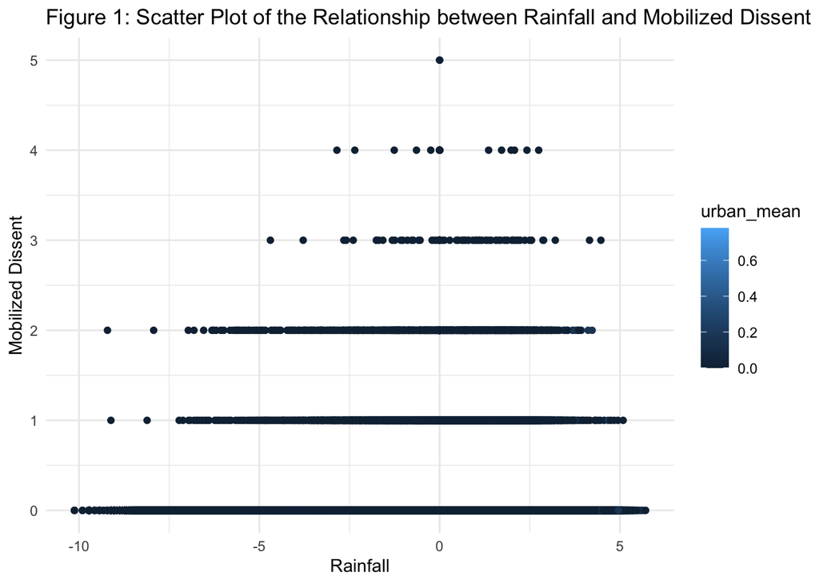

```r
#Plot
ggplot(africa_new, aes(x = lograin + rainannualpct, y = dissentcount, colour = urban_mean)) +
geom_point(alpha= 1)  +
  theme_minimal() +
  labs(x = "Rainfall", y = "Mobilized Dissent") +
    theme(plot.caption= element_text(size=10)) +
  ggtitle("Figure 1: Scatter Plot of the Relationship between Rainfall and Mobilized Dissent")
```

### Descriptive plot of the relationship between *Mobilized dissent* and *Repression*

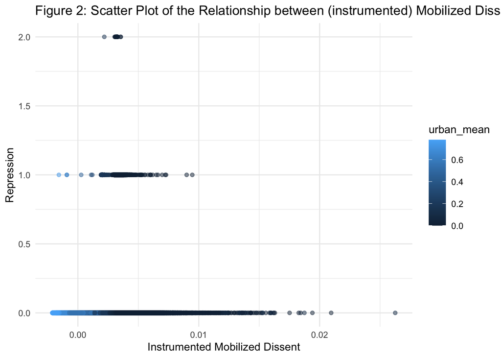

```r
#Regressing the instrument on dissentcount
basic_first_stage <- lm(dissentcount ~ lograin + rainannualpct + urban_mean , data = africa_new)

#Extracting the predicted values and ensuring alignment
instrument <- fitted(basic_first_stage)

ggplot(africa_new, aes(x = instrument, y = represscount, colour = urban_mean)) +
geom_point(alpha= 0.5)  +
  theme_minimal() +
  labs(x = "Instrumented Mobilized Dissent", y = "Repression") +
  ggtitle("Figure 2: Scatter Plot of the Relationship between (instrumented) Mobilized Dissent and Repression")
```

### Extension

It seems reasonable to consider a third confounder in the relationship between dissent and and repression. This variable is economic inequality, opeationalized as ‘uw_gini’.

**Variable Selection** The chosen variable for the extansion is ‘uw_gini’ from QoGData, as reported by UNU-WIDER (World Income Inequality Database, version WIID2c). This variable represents the GINI Index, a frequently used gauge of income disparity. The index’s foundation is the comparison of cumulative proportions of the population versus the cumulative proportions of income they receive. Its values range from 0, symbolizing complete equality, to 1, denoting absolute inequality (Inequality - Income Inequality - OECD Data, 2015).

**Theoretical Framework** Prior research has extensively explored the role that disparities among social groups have in promoting collective action. The results show that inequality is the primary factor impacting trust, whereby an increase in inequality leads to a decline in civic engagement (Uslaner & Brown, 2005).

In situations where income inequality is minimal, the probability of repression increases when inequality decrease; when inequality is moderate, the chance of repression is minimal; but when inequality is high, the chance of repression is also high. This relationship between the degree of income inequality and the likelihood of repression can be characterized as a U-shaped curve, that is, as the magnitude of grievances increases from low to high, the likelihood of repression first decreases and then increases (Shadmehr, 2014). If authoritative measures are effective in suppressing protests, government repression might be capable of preventing economic inequalities from spiraling into violence (Lichbach, 1989).

Levin-Waldman (2016) argues that inequality poses a danger to democracy in terms of how institutions and individuals respond to an upswing in inequality. Moreover, the distribution of political power and the democratic or autocratic character of the state are crucial elements; if the less affluent engage in peaceful protest, the state may respond, eliminating the necessity for these individuals to resort to violent demonstrations (Lichbach, 1989). Lastly, the independent or instrumental character of the government is swayed by the dynamics of class-state interactions, which may also correlate with policy undertakings (Lichbach, 1989).

The subsequent DAG portrays the variable configuration for the above theoretical proposition:

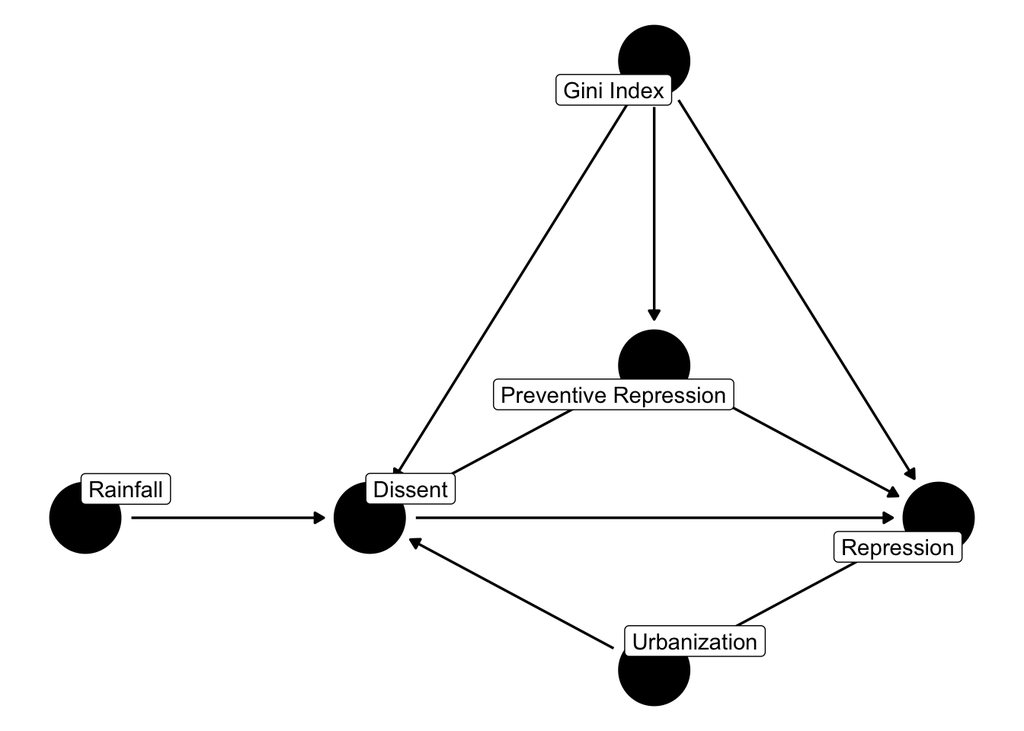

```r
coord_dag2 <- list(
  x = c(rain = 0, diss = 1, dem = 2, urb = 2, gini = 2, repr = 3),
  y = c(rain = 0, diss = 0, dem = 1, urb = -1, gini = 3, repr = 0))


dag_ext <- ggdag::dagify(diss ~ rain,
                      repr ~ diss,
                      diss ~ dem,
                      repr ~ dem,
                      diss ~ urb,
                      repr ~ urb,
                      repr ~ gini,
                      diss ~ gini,
                      dem ~ gini,
                      labels = c("rain" = "Rainfall",
                                  "diss" = "Dissent",
                                  "dem" = "Preventive Repression",
                                  "urb" = "Urbanization",
                                  "repr" = "Repression",
                                  "gini" = "Gini Index"),
                          latent = "dem",
                          exposure = "diss",
                          outcome = "repr",
                          coords = coord_dag2)

ggdag(dag_ext, text = FALSE, use_labels = "label") +
theme_void()
```

```r
# Create a new dataset including the variable 'uw_gini'
africa_extension <-  africa_matching %>%
  left_join(QoGData, by = c("cow", "year")) %>%
  select(adm0_adm1, year, cow, date, represscount, dissentcount, urban_mean, lograin, rainannualpct, raintreatment, latent_democracy, pop_sum, dem, nondem, uw_gini) %>%
  na.omit()

# Conducting Coarsened Exact Matching (CEM)
cem_extension <- MatchIt::matchit(raintreatment ~ urban_mean + pop_sum  + uw_gini, method = "cem", data = africa_extension)
cem_df_extension <- MatchIt::match.data(cem_extension)

# Non-democracies
# First stage: regressing the instrument on dissentcount
nondem_ext_stage1 <- lm(dissentcount ~ lograin + rainannualpct + urban_mean + nondem + uw_gini, data = cem_df_extension)

# Second stage
nondem_ext_iv <- lfe::felm(represscount ~ uw_gini | 0 |
                              (dissentcount ~ lograin + rainannualpct) | 0,
                            data = cem_df_extension[cem_df_extension$latent_democracy <= 0, ])

# Democracies
# First stage: regressing the instrument on dissentcount
dem_ext_stage1 <- lm(dissentcount ~ lograin + rainannualpct + urban_mean + dem + uw_gini, data = cem_df_extension)

# Second stage
dem_ext_iv <- lfe::felm(represscount ~ uw_gini | 0 |
                            (dissentcount ~ lograin + rainannualpct) | 0,
                          data = cem_df_extension[cem_df_extension$latent_democracy > 0,])

# Table
extension <- list(nondem_IV_matched, dem_IV_matched, nondem_ext_iv, dem_ext_iv)

# Generate the regression outputs with customizations
table_extension <-  stargazer(extension, type = "html",
                    covariate.labels = c("Urbanization", "Fitted Mobilized Dissent"),
                    column.labels = c("Non-Democracies (NO Gini)", "Matched IV Democracies (NO Gini)", "Non-Democracies (WITH Gini)", "Matched IV Democracies (WITH Gini)"),
                    dep.var.labels.include = FALSE,
                    dep.var.caption = "Second Stage Regressions for matched models without and with Gini coefficient",
                    title = "Table 3: Effect of Mobilized Dissent on State Repression in African Province-Days considering the Gini coefficient",
                    caption = "The last two columns are the matched regression controlling for the covariate of income inequality.")
```

**Table 3: Effect of Mobilized Dissent on State Repression in African Province-Days considering the Gini coefficient**

[output not shown]

**Table 3: Effect of Mobilized Dissent on State Repression in African Province-Days considering the Gini coefficient**

| The last two columns are the matched regression controlling for the covariate of income inequality. |
| --- |

**Caveats** While including income inequality yields crucial information regarding resource distribution in a society, the GINI index has certain limitations. Some of the key constraints of the GINI index include: - It is purely dependent on income or wealth, overlooking other aspects of inequality such as education, health, and social mobility. - Its primary focus is on the income distribution’s extremities and it may not adequately reflect shifts in the middle-income brackets. - It is unable to record changes in inequality that take place within specific groups or subpopulations, potentially hiding disparities present within these groups.

These GINI coefficients draw upon multiple sources of information and relate to a range of income and population categories, sample sizes, and statistical methodologies (QoG,2011). Consequently, comparisons within and between countries should be approached with caution due to the lack of global comparability.

Moreover, it would have been necessary also to control for poverty levels, as the influence of income inequality on dissent and repression can me thought as moderated by absolute avreage income levels. However, due to a persistent error in the code that I was unable to solve, I could not include this control in the regression. This might have modified the results. It is however hard to assess the bias, as the relationship between income inequality and repression is theorized as U-shaped, and being it non-linear. Further research can be done in this direction. However, it is fundamental to understand that income inequality plays a role in this relationship, and therefore not accounting for it will result in inaccurate results.

### Software statement

The analysis was run under OS X 13.3.1 using R Version 2023.03.0+386 (R Core Team 2023). Copyright (C) 2022 by Posit Software, PBC. The following R software packages were used: dplyr (Wickham et al. 2022), tidyverse (Wickham et al. 2019), haven (Wickham & Smith 2022), lmtest (Zeileis & Hothorn 2022), MatchIt (Ho et al. 2011), lfe (Gaure 2013), ggdag (Barrett 2023), stargazer (Hlavac & Marek 2022), plm (Croissant 2018), AER (Kleiber & Zeileis 2008), tsibble (Wang, Cook, Hyndman 2020).

### Bibliographic References

Conrad, Courtenay, 2016, “Replication Data for: Preventing and Responding to Dissent: The Observational Challenges of Explaining Strategic Repression”, https://doi.org/10.7910/DVN/T1JZ0L, Harvard Dataverse, V1, UNF:6:2A/44MVBte7gi5ImqGrHPA== [fileUNF]

Inequality - Income inequality - OECD Data. (2015). TheOECD. https://data.oecd.org/inequality/income-inequality.htm

Levin-Waldman, O. (2016). How Inequality Undermines Democracy Written by How Inequality Undermines Democracy. https://www.e-ir.info/pdf/66901

Lichbach, M. I. (1989). An Evaluation of “Does Economic Inequality Breed Political Conflict?” Studies. World Politics, 41(4), 431–470. https://doi.org/10.2307/2010526

Shadmehr, M. (2014). Mobilization, Repression, and Revolution: Grievances and Opportunities in Contentious Politics. The Journal of Politics, 76(3), 621–635. https://doi.org/10.1017/s0022381614000267

Uslaner, E. M., & Brown, M. (2005). Inequality, Trust, and Civic Engagement. American Politics Research, 33(6), 868–894. https://doi.org/10.1177/1532673X04271903 Uslaner, E. M., & Brown, M. (2005). Inequality, Trust, and Civic Engagement. American Politics Research, 33(6), 868–894. https://doi.org/10.1177/1532673X04271903

The Quality of Government Dataset Codebook. (2011). https://www.qogdata.pol.gu.se/dataarchive/codebook_standard_6apr11.pdf